# Data Science - Capstone - Project Movielens

## **II. Modeling movie effects**

We know that some movies are just generally rated higher than others. Our first model can be improved by adding a term $\mathbf {b_i}$ that represents the average ranking for movie . The improved model can be described as follows:

$\mathbf{Y{_u,_i} = \mu + b {_i} + \epsilon {_u,_i}}$

We know that the least squares estimate $\mathbf{\hat b_i}$ is just the average of $\mathbf{Y{_u,_i} - \hat\mu}$ for each movie.

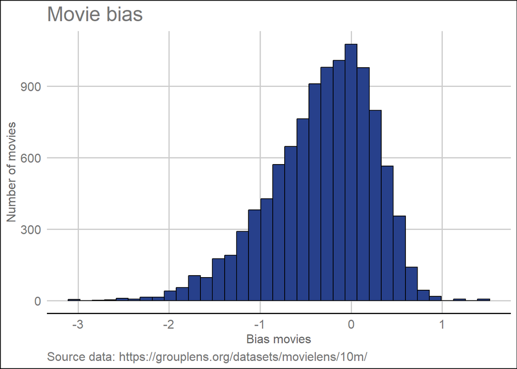

```r
#########################################################
# II. Modeling movie effects
#########################################################

#The least squares estimate ^b_i is just the average of Y(u,i) - ^mu for each movie
mu <- mean(edx$rating)
movie_bias <- edx %>%
  group_by(movieId) %>%
  summarize(b_i = mean(rating - mu))

#Histogram graphic show 0 equivalent 3.51 mean rating movie, 1.5 is equal to 5 rating and -3 is equal to 0.5 rating
ggplot(movie_bias, aes(x = b_i)) +
  geom_histogram(bins = 35, fill = "#27408B", color = "black") +
  labs(title = "Movie bias",
       x = "Bias movies",
       y = "Number of movies",
       caption = "Source data: https://grouplens.org/datasets/movielens/10m/") +
  theme(axis.title.x=element_text(size=12, angle=0, face = "bold"))+
  theme(axis.text.x=element_text(size=10, angle=0, face = "bold")) +
  theme(axis.text.y=element_text(size=10, angle=90, face = "bold"))+
  theme_gdocs()
```

```r
#create a predicted rating add mu + b_i (bias movie)
predicted_ratings <- mu + final_holdout_test %>%
  left_join(movie_bias, by='movieId') %>%
  pull(b_i)

#calculate RMSE with predicted_ratings and test set final_holdout_test
model_1 <- RMSE(predicted_ratings, final_holdout_test$rating)

model_1_rmse <- tibble(Model = "Movie Effect Model", RMSE = model_1)

model_1_rmse %>% kable()
```

| Model | RMSE |
| --- | --- |
| Movie Effect Model | 0.94391 |

We could see in the histogram graphic, these estimates for movies vary substantially. We know that some movies are good whereas others are not.

We had estimated the $\mathbf{\hat\mu}$ , the average of all ratings, as 3.5. So a $\mathbf{\hat bi}$ of 1.5 implies $\mathbf{\hat y{_u,_i} = \hat\mu + \hat b{_i} = 3.5 + 1.5 = 5}$ which is a perfect five-star rating. Our prediction improves once we use $\mathbf{\hat y{_u,_i} = \hat\mu + \hat b {_i}}$

## **III. Modeling user effects**

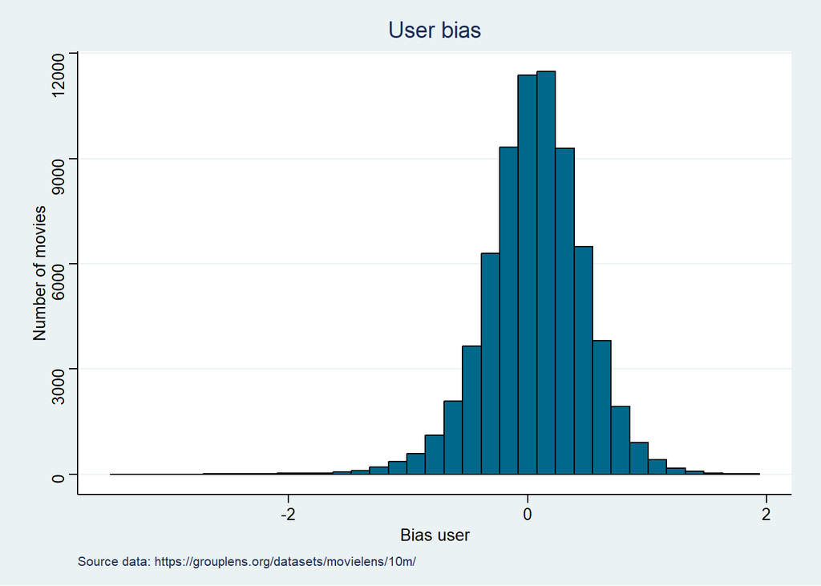

```r
#########################################################
# III. Modeling user effects
#########################################################

#We will compute an approximation by computing ^mu  and ^b_i and estimating ^b_u as the average of  ^y(u,i)- ^mu - ^b_i
user_bias <- edx %>%
  left_join(movie_bias, by='movieId') %>%
  group_by(userId) %>%
  summarize(b_u = mean(rating - mu - b_i))

#Histogram graphic bias user
ggplot(user_bias, aes(x = b_u)) +
  geom_histogram(bins = 35, fill = "#00688B", color = "black") +
  labs(title = "User bias",
       x = "Bias user",
       y = "Number of movies",
       caption = "Source data: https://grouplens.org/datasets/movielens/10m/") +
  theme(axis.title.x=element_text(size=12, angle=0, face = "bold"))+
  theme(axis.text.x=element_text(size=10, angle=0, face = "bold")) +
  theme(axis.text.y=element_text(size=10, angle=90, face = "bold"))+
  theme_stata()
```

```r
#create a predicted rating add mu + b_i (bias movie) + b_u (bias user)
predicted_ratings <- final_holdout_test %>%
  left_join(movie_bias, by='movieId') %>%
  left_join(user_bias, by='userId') %>%
  mutate(pred = mu + b_i + b_u) %>%
  pull(pred)

#calculate RMSE with predicted_ratings and test set final_holdout_test
model_2 <- RMSE(predicted_ratings, final_holdout_test$rating)

model_2_rmse <- tibble(Model = "Movie + User Effect Model", RMSE = model_2)

model_2_rmse %>% kable()
```

| Model | RMSE |
| --- | --- |
| Movie + User Effect Model | 0.86535 |

We compute an approximation by computing $\mathbf{\hat\mu}$ and $\mathbf{\hat b{_i}}$ and estimating $\mathbf{\hat b{_u}}$ as the average of $\mathbf{\hat y{_u,_i} - \hat\mu - \hat b{_i}}$

The substantial variability across users is quiet evident from the above plot. This implies that a further improvement to our model may be:

$\mathbf{Y{_u,_i} = \mu + b{i} + b{u} + \epsilon {_u,_i}}$

## **IV. Regularized movie + user effect model**

Regularization permits us to penalize large estimates that are formed using small sample sizes.

In order to account for this effect, regularization will be introduced into the model. The formula of the regularization introduced is:

$\frac{1}{\lambda + n_{i}}\sum_{u=1}^{ni}(Y{_u,_i} - \hat\mu)$

The idea is to add a tuning parameter $\mathbf{\lambda}$ to further reduce the RMSE. The idea is to penalize outliers from the movie bias and user bias sets which shall optimise the recommendation system.

```r
#########################################################
# IV. Regularized movie + user effect model
#########################################################

#The idea is to add a tuning parameter lamba to further reduce the RMSE
#The idea is to penalize outliers from the Movie Bias and User Bias sets which shall optimize the recommendation system
lambdas_regularize <- seq(0, 10, 0.25)

rmse_regularize <- sapply(lambdas_regularize, function(l){

  edx_mu <- mean(edx$rating)

  b_i <- edx %>%
    group_by(movieId) %>%
    summarize(b_i = sum(rating - edx_mu)/(n()+l))

  b_u <- edx %>%
    left_join(b_i, by="movieId") %>%
    group_by(userId) %>%
    summarize(b_u = sum(rating - edx_mu - b_i)/(n()+l))

  predicted_ratings <- final_holdout_test %>%
    left_join(b_i, by = "movieId") %>%
    left_join(b_u, by = "userId") %>%
    mutate(pred = edx_mu + b_i + b_u) %>%
    pull(pred)

  return(RMSE(predicted_ratings, final_holdout_test$rating))
})

#Discover which lamba will be best at reducing the RMSE
lambda <- lambdas_regularize[which.min(rmse_regularize)]
lambda
```

```
## [1] 5.25
```

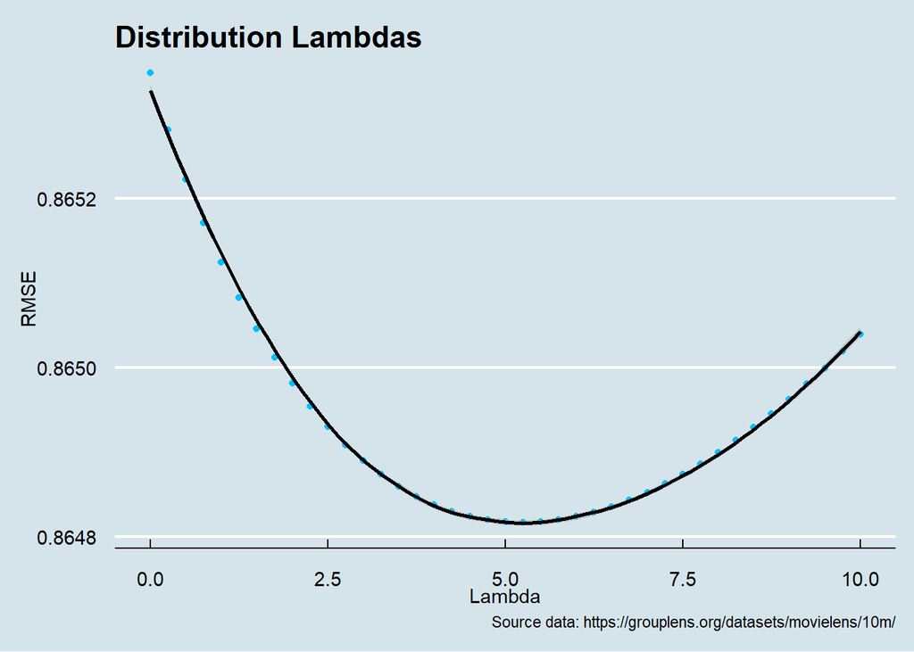

```r
ggplot(mapping = aes(x = lambdas_regularize, y = rmse_regularize)) +
  geom_point(color = "#00BFFF") +
  labs(title = "Distribution Lambdas",
       x = "Lambda",
       y = "RMSE",
       caption = "Source data: https://grouplens.org/datasets/movielens/10m/") +
  geom_smooth(color = "black") +
  theme_economist()
```

```r
#We will use the best lamba to reduce our RMSE regularized Movie + User Effect Model
b_i <- edx %>%
  group_by(movieId) %>%
  summarize(b_i = sum(rating - mu)/(n()+lambda))

b_u <- edx %>%
  left_join(b_i, by="movieId") %>%
  group_by(userId) %>%
  summarize(b_u = sum(rating - mu - b_i)/(n()+lambda))

predicted_ratings <- final_holdout_test %>%
  left_join(b_i, by = "movieId") %>%
  left_join(b_u, by = "userId") %>%
  mutate(pred = mu + b_i + b_u) %>%
  pull(pred)

#calculate RMSE with predicted_ratings and test set final_holdout_test
model_3 <- RMSE(predicted_ratings, final_holdout_test$rating)

model_3_rmse <- tibble(Model = "Regularized Movie + User Effect Model", RMSE = model_3)

model_3_rmse %>% kable()
```

| Model | RMSE |
| --- | --- |
| Regularized Movie + User Effect Model | 0.86482 |

## **V. Regularized movie + user effect model + genres effect model**

Regularization permits us to penalize large estimates that are formed using small sample sizes.

The idea is to add a tuning parameter $\mathbf{\lambda}$ to further reduce the RMSE. The idea is to penalize outliers from the movie bias,user and genres bias sets which shall optimize the recommendation system.

```r
##################################################################
# V. Regularized movie + user effect model + genres effecft model
#################################################################

#The idea is to add a tuning parameter lamba to further reduce the RMSE
#The idea is to penalize outliers from the Movie, User and genres Bias sets which shall optimize the recommendation system

#We will use the best lamba to reduce our RMSE regularized Movie + User Effect Model + Genres Effect Model

b_i <- edx %>%
  group_by(movieId) %>%
  summarize(b_i = sum(rating - mu)/(n()+lambda))

b_u <- edx %>%
  left_join(b_i, by="movieId") %>%
  group_by(userId) %>%
  summarize(b_u = sum(rating - mu - b_i)/(n()+lambda))

b_g <- edx %>%
  left_join(b_i, by="movieId") %>%
  left_join(b_u, by="userId") %>%
  group_by(real_genres) %>%
  summarize(b_g = sum(rating - mu - b_i - b_u)/(n()+lambda))

predicted_ratings <- final_holdout_test %>%
  left_join(b_i, by = "movieId") %>%
  left_join(b_u, by = "userId") %>%
  left_join(b_g, by = "real_genres") %>%
  mutate(pred = mu + b_i + b_u + b_g) %>%
  pull(pred)

#calculate RMSE with predicted_ratings and test set final_holdout_test

model_4 <- RMSE(predicted_ratings, final_holdout_test$rating)

model_4_rmse <- tibble(Model = "Regularized Movie + User Effect Model + Genres Effect Model", RMSE = model_4)

model_4_rmse %>% kable()
```

| Model | RMSE |
| --- | --- |
| Regularized Movie + User Effect Model + Genres Effect Model | 0.86471 |

# **5. RECO(system using matrix factorization)**

reco is an R package which implements many algorithms for sparse matrix factorizations. Focus is on applications for recommender systems.

```r
#########################################################
# 5. RECO
#########################################################

niter <- 25
# Train the reco model with the fixed niter on the entire edx set
reco_train <- data_memory(edx$userId, edx$movieId, edx$rating)
reco_model <- Reco()

reco_model$train(reco_train, opts = list(dim = 10, niter = niter,  nthread = 8, costp_l2 = 0.1, costq_l2 = 0.1, lrate = 0.05))
```

```
## iter      tr_rmse          obj
##    0       1.0367   1.6560e+07
##    1       0.8875   1.3680e+07
##    2       0.8776   1.3403e+07
##    3       0.8710   1.3278e+07
##    4       0.8599   1.3143e+07
##    5       0.8492   1.3008e+07
##    6       0.8426   1.2927e+07
##    7       0.8386   1.2875e+07
##    8       0.8359   1.2841e+07
##    9       0.8338   1.2814e+07
##   10       0.8323   1.2798e+07
##   11       0.8311   1.2782e+07
##   12       0.8299   1.2769e+07
##   13       0.8290   1.2760e+07
##   14       0.8282   1.2753e+07
##   15       0.8275   1.2745e+07
##   16       0.8268   1.2739e+07
##   17       0.8263   1.2735e+07
##   18       0.8258   1.2731e+07
##   19       0.8253   1.2727e+07
##   20       0.8248   1.2720e+07
##   21       0.8245   1.2720e+07
##   22       0.8240   1.2713e+07
##   23       0.8237   1.2710e+07
##   24       0.8234   1.2707e+07
```

```r
# Prepare final hold-out test data
reco_test <- data_memory(final_holdout_test$userId, final_holdout_test$movieId)

# Predict ratings for the final hold-out test set
predicted_holdout_ratings <- reco_model$predict(reco_test)

# Add predictions to final hold-out test set
final_holdout_test$predicted_rating <- predicted_holdout_ratings

# Calculate RMSE for the final hold-out test set
model_reco <-  RMSE(final_holdout_test$predicted_rating, final_holdout_test$rating)
model_reco_rmse <- tibble(Model = "Reco matrix factorization", RMSE = model_reco)

model_reco_rmse %>% kable()
```

| Model | RMSE |
| --- | --- |
| Reco matrix factorization | 0.83595 |

# **6. RESULTS**

```r
#########################################################
# 6. RESULTS
#########################################################

#Summarize the models RMSE

results_rmse <- tibble(Model = c("Naive RMSE", "Movie Effect Model", "Movie + User Effect Model", "Regularized Movie + User Effect Model",
                                 "Regularized Movie + User Effect Model + Genres Effect Model", "Reco matrix factorization"),
                       RMSE = c(result_nai, model_1, model_2, model_3, model_4, model_reco))

results_rmse %>% kable()
```

| Model | RMSE |
| --- | --- |
| Naive RMSE | 1.06120 |
| Movie Effect Model | 0.94391 |
| Movie + User Effect Model | 0.86535 |
| Regularized Movie + User Effect Model | 0.86482 |
| Regularized Movie + User Effect Model + Genres Effect Model | 0.86471 |
| Reco matrix factorization | 0.83595 |

# **7. CONCLUSION**

We could see from the models used that adding more variables increases the accuracy of the result.

# **8. REFERENCES**

[1] Yixuan Qiu, David Cortes, Chih-Jen Lin, Yu-Chin Juan, Wei-Sheng Chin, Yong Zhuang, Bo-Wen Yuan, Meng-Yuan Yang. Reco (system using a matrix factorization):

[https://cran.rproject.org/web/packages/recosystem/recosystem.pdf](https://cran.r-project.org/web/packages/recosystem/recosystem.pdf)